# Estimating Customer Lifetime Value - Part 2

```python
import pandas as pd
import matplotlib.pyplot as plt
import seaborn as sns
import numpy as np
import spacy

from sklearn.base import BaseEstimator, TransformerMixin
from sklearn.pipeline import FeatureUnion, Pipeline
from sklearn.impute import SimpleImputer
from sklearn.preprocessing import OneHotEncoder, RobustScaler
from sklearn.compose import make_column_transformer
from sklearn.ensemble import GradientBoostingRegressor
from sklearn.metrics import mean_absolute_error

import warnings
warnings.filterwarnings('ignore')
```

# Dataset

This online retail dataset is from the UC Irvine Machine Learning Repository: https://archive.ics.uci.edu/dataset/502/online+retail+ii.

Having done exploratory analysis in Part 1, we will now try to estimate customers' gross spend in the next one year using three months of data.

We will preprocess the data as learned from part 1.

```python
df1 = pd.read_excel('./online_retail_II.xlsx', sheet_name=0) # Year 2009-2010
df2 = pd.read_excel('./online_retail_II.xlsx', sheet_name=1) # Year 2010-2011
df = pd.concat([df1, df2])
```

```python
def include_stock_code(code):
    if len(code) < 5 or len(code) > 8:
        return False

    if 'TEST' in code:
        return False

    for c in code:
        if c.isnumeric():
            return True

    return False


def filter_transactions(df):
    df = df.loc[(df['Quantity'] > 0) & (~df['Customer ID'].isna())]
    df = df[df.apply(lambda x: include_stock_code(str(x['StockCode'])), axis=1)]

    return df


def aggregate(features_df, labels_df):
    features_df = filter_transactions(features_df)
    labels_df = filter_transactions(labels_df)

    cutoff_date = features_df['InvoiceDate'].max()
    features_df['item_amount'] = features_df['Price'] * features_df['Quantity']
    features = features_df\
        .groupby('Customer ID')\
        .apply(lambda x: pd.Series(
            {
                'total_amount': x['item_amount'].sum(),
                'num_orders': x['Invoice'].nunique(),
                'avg_value': x['item_amount'].sum()/x['Invoice'].nunique(),
                'customer_retention': (cutoff_date - x['InvoiceDate'].min()).days,
                'avg_lead_time': (cutoff_date - x['InvoiceDate'].min()).days/x['Invoice'].nunique(),
                'country': x['Country'].max(),
                'description': ' '.join(x['Description'].fillna('')),
            }))\
        .reset_index()

    labels = labels_df\
        .groupby('Customer ID')\
        .apply(lambda x: pd.Series(
            {
                'total_target_amount': (x['Price']*x['Quantity']).sum(),
            }))\
        .reset_index()

    mergeddf = pd.merge(features, labels, on='Customer ID', how='left')
    mergeddf['total_target_amount'] = mergeddf['total_target_amount'].fillna(0)

    return mergeddf
```

We stack together 3 three-month period as the train set and set aside another three-month period as the test set. The subsequent twelve months for each set are used to calculate the label.

```python
df_train = None
for dt in ['2009-12-01', '2010-03-01', '2010-06-01']:
    train_start_date = pd.to_datetime(dt)
    train_cutoff_date = train_start_date+pd.DateOffset(months=3)
    label_cutoff_date = pd.to_datetime(train_cutoff_date)+pd.DateOffset(months=12)
    features_df_train = df.loc[(df['InvoiceDate'] > train_start_date) & (df['InvoiceDate'] < train_cutoff_date)]
    labels_df_train = df.loc[(df['InvoiceDate'] > train_cutoff_date) & (df['InvoiceDate'] < label_cutoff_date)]

    print(train_start_date, label_cutoff_date)
    tmp = aggregate(features_df_train, labels_df_train)
    df_train = pd.concat([df_train, tmp]) if df_train is not None else tmp
```

```
2009-12-01 00:00:00 2011-03-01 00:00:00
2010-03-01 00:00:00 2011-06-01 00:00:00
2010-06-01 00:00:00 2011-09-01 00:00:00
```

```python
df_test = None
for dt in ['2010-09-01']:
    train_start_date = pd.to_datetime(dt)
    train_cutoff_date = train_start_date+pd.DateOffset(months=3)
    label_cutoff_date = pd.to_datetime(train_cutoff_date)+pd.DateOffset(months=12)
    features_df_train = df.loc[(df['InvoiceDate'] > train_start_date) & (df['InvoiceDate'] < train_cutoff_date)]
    labels_df_train = df.loc[(df['InvoiceDate'] > train_cutoff_date) & (df['InvoiceDate'] < label_cutoff_date)]

    print(train_start_date, label_cutoff_date)
    tmp = aggregate(features_df_train, labels_df_train)
    df_test = pd.concat([df_test, tmp]) if df_train is not None else tmp
```

```
2010-09-01 00:00:00 2011-12-01 00:00:00
```

```python
df_train['country'].unique()
```

```
array(['Austria', 'Cyprus', 'Belgium', 'Australia', 'RSA', 'Denmark',
       'Germany', 'France', 'Norway', 'Unspecified', 'Sweden', 'Spain',
       'USA', 'Italy', 'Finland', 'United Kingdom', 'Japan', 'Portugal',
       'Netherlands', 'Poland', 'United Arab Emirates', 'Switzerland',
       'EIRE', 'Greece', 'Channel Islands', 'Malta', 'Bahrain',
       'Singapore', 'Thailand', 'Israel', 'Lithuania', 'Nigeria',
       'West Indies'], dtype=object)
```

# Modeling Pipeline

We set up a feature processing pipeline using scikit learn.

- For numerical features, we scale them using RobustScaler.
- For categorical features, we convert them using one-hot encoder.
- For text features, we convert them to Glove embedding vectors.

Finally, we fit the data to a gradient boosting tree model for predictions.

```python
numerical_features = ["total_amount", "num_orders", "customer_retention", "avg_value", "avg_lead_time"]
categorical_features = ["country"]
text_features = 'description'
```

```python
# class GloveVectorTransformer(BaseEstimator, TransformerMixin):
#     def __init__(self):
#         self.dim = 300

#     def fit(self, X, y=None):
#         return self

#     def transform(self, X, y=None):
#         nlp = spacy.load("en_core_web_lg")
#         return np.array([nlp(text).vector for text in X])

from glove_transformer import GloveVectorTransformer
```

```python
# categorical pipeline
categorical_preprocessing = Pipeline(
[
    ('Imputation', SimpleImputer(strategy='constant', fill_value='Unknown')),
    ('One Hot Encoding', OneHotEncoder(handle_unknown='ignore')),
]
)
# numeric pipeline
numeric_preprocessing = Pipeline(
[
     ('Imputation', SimpleImputer(strategy='median')),
     ('Scaling', RobustScaler())
]
)
# text pipeline
text_preprocessing = Pipeline(
[
     ('Text',GloveVectorTransformer())
]
)
# feature processing pipeline
feature_processing = make_column_transformer(
     (numeric_preprocessing, numerical_features),
     (categorical_preprocessing, categorical_features),
     (text_preprocessing, text_features),
)
```

```python
# Final pipeline
pipeline = Pipeline(
[('Preprocessing', feature_processing),
 ("model", GradientBoostingRegressor(
     random_state=0,
     loss='absolute_error',
     n_estimators=1000,
     max_depth=3,
     learning_rate=0.01
 )),
]
)

pipeline.fit(df_train, df_train['total_target_amount'])
```

```
Pipeline(steps=[('Preprocessing',
                 ColumnTransformer(transformers=[('pipeline-1',
                                                  Pipeline(steps=[('Imputation',
                                                                   SimpleImputer(strategy='median')),
                                                                  ('Scaling',
                                                                   RobustScaler())]),
                                                  ['total_amount', 'num_orders',
                                                   'customer_retention',
                                                   'avg_value',
                                                   'avg_lead_time']),
                                                 ('pipeline-2',
                                                  Pipeline(steps=[('Imputation',
                                                                   SimpleImputer(fill_value='Unknown',
                                                                                 strategy='constant')),
                                                                  ('One Hot '
                                                                   'Encoding',
                                                                   OneHotEncoder(handle_unknown='ignore'))]),
                                                  ['country']),
                                                 ('pipeline-3',
                                                  Pipeline(steps=[('Text',
                                                                   GloveVectorTransformer())]),
                                                  'description')])),
                ('model',
                 GradientBoostingRegressor(learning_rate=0.01,
                                           loss='absolute_error',
                                           n_estimators=1000,
                                           random_state=0))])
```

```python
ytrain_pred = pipeline.predict(df_train)
ytest_pred = pipeline.predict(df_test)
```

We can measure the model performance using mean absolute errors, and compare the GBT model and the naive extrapolation, where the next 12 month spend is simply the proportional adjustment of the last 3 month spend.

GBT model is able to learn and predict better than our naive basline.

```python
# training and test errors from GBT model
train_error = mean_absolute_error(ytrain_pred, df_train["total_target_amount"])
test_error = mean_absolute_error(ytest_pred, df_test["total_target_amount"])
train_error, test_error
```

```
(1732.610813318166, 1551.1265385233871)
```

```python
# training and test errors from naive extrapolation
train_error = mean_absolute_error(df_train['total_amount'] * 12 / 3, df_train['total_target_amount'])
test_error = mean_absolute_error(df_test['total_amount'] * 12 / 3, df_test['total_target_amount'])
train_error, test_error
```

```
(2169.6503582089554, 2386.816638859924)
```

We can take a quick look at the top variables guiding the model with GBT's feature importance.

GBT's feature importance is estimated by the number of times a feature is used in making a split and the number of samples the split affects.

[output not shown]

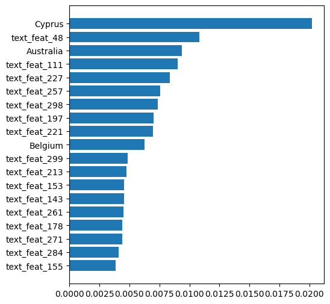

```python
NUM_FEATURES = 20
reg = pipeline.named_steps['model']
flist = list(df_train["country"].unique()) + numerical_features + [f'text_feat_{i}' for i in range(1, 301)]

feature_importance = reg.feature_importances_
sorted_idx = np.argsort(feature_importance)[-NUM_FEATURES:-1]
pos = np.arange(sorted_idx.shape[0]) + 0.5
fig = plt.figure(figsize=(12, 6))
plt.subplot(1, 2, 1)
plt.barh(pos, feature_importance[sorted_idx], align="center")
plt.yticks(pos, np.array(flist)[sorted_idx])
```

The text features we extracted from the description field came up pretty often as the top contributors. Let's take a quick look at the text_feat_48.

```python
ith = (300-48)
X_train = feature_processing.fit_transform(df_train)
```

```python
# samples where 48th embedding vector if weight < 0
neg_weights = [(list(df_train['description'])[i]) for i in range(df_train.shape[0]) if X_train[:, -ith][i] < 0]
neg_weights[:10]
```

```
['WATERING CAN PINK BUNNY WATERING CAN GREEN DINOSAUR S/6 WOODEN SKITTLES IN COTTON BAG EASTER TIN BUCKET SET/3 RUSSIAN DOLL STACKING TINS VINTAGE HEADS AND TAILS CARD GAME ',
 'HOT BATHS SOAP HOLDER KITCHEN METAL SIGN HAND OVER THE CHOCOLATE   SIGN  EMERGENCY FIRST AID TIN  BATHROOM METAL SIGN LOO ROLL  METAL SIGN  BEWARE OF THE CAT METAL SIGN  POTTERING IN THE SHED METAL SIGN MAN FLU METAL SIGN CHOCOLATE THIS WAY METAL SIGN LAUNDRY 15C METAL SIGN',
 'BLUE NEW BAROQUE CANDLESTICK CANDLE FAIRY CAKE DESIGN UMBRELLA PINK FAIRY CAKE CUSHION COVER 60 TEATIME FAIRY CAKE CASES MINI CAKE STAND  HANGING STRAWBERY CAKE STAND LACE WHITE',
 'HEART IVORY TRELLIS SMALL FOLKART ZINC HEART CHRISTMAS DEC ZINC METAL HEART DECORATION WHITE PEARL BEADED HEART, SMALL BEADED PEARL HEART WHITE LARGE WHITE HANGING HEART T-LIGHT HOLDER',
 "RED HANGING HEART T-LIGHT HOLDER HANGING HEART ZINC T-LIGHT HOLDER PAPER CHAIN KIT 50'S CHRISTMAS ",
 'SKULLS WRAP',
 'ANT WHITE WIRE HEART SPIRAL VINTAGE POST OFFICE CABINET',
 'RED CHARLIE+LOLA PERSONAL DOORSIGN STRAWBERRY CANDY BAG SUKI  SHOULDER BAG AFGHAN SLIPPER SOCK PAIR SAVE THE PLANET MUG SAVE THE PLANET COTTON TOTE BAG SUKI  SHOULDER BAG STRAWBERRY CANDY BAG CHARLIE AND LOLA CHARLOTTE BAG',
 'SUKI  SHOULDER BAG RED SPOTTY CANDY BAG RED SPOTTY SHOPPER BAG LUNCH BAG RED SPOTTY LUNCH BAG  BLACK SKULL. WOODLAND WATER TRANSFER TATTOOS  SKULLS  WATER TRANSFER TATTOOS   ANIMAL STICKERS  WHITE CHERRY LIGHTS CHILLI LIGHTS SAVE THE PLANET COTTON TOTE BAG SKULL SHOULDER BAG',
 'SANDALWOOD FAN']
```

```python
# samples where 48th embedding vector if weight < 0
pos_weights = [(list(df_train['description'])[i]) for i in range(df_train.shape[0]) if X_train[:, -ith][i] > 0.5]
pos_weights[:10]
```

```
['BABY BOOM RIBBONS  URBAN BLACK RIBBONS  PINK CREAM FELT CRAFT TRINKET BOX  FELTCRAFT BUTTERFLY HEARTS LOVE BUILDING BLOCK WORD HOME BUILDING BLOCK WORD NURSERY A,B,C PAINTED LETTERS VINTAGE CREAM 3 BASKET CAKE STAND SET OF 6 GIRLS CELEBRATION CANDLES 6 RIBBONS SHIMMERING PINKS  6 RIBBONS ELEGANT C…
 'TEATIME CAKE TIN WITH HANDLE STRAWBERRY CERAMIC TRINKET BOX PINK DOUGHNUT TRINKET POT  GREEN MINI TAPE MEASURE  SILVER MINI TAPE MEASURE  FAWN BLUE HOT WATER BOTTLE PINK HEART CANDY BUTTON CALCULATOR 3D DOG PICTURE PLAYING CARDS INFLATABLE POLITICAL GLOBE  CAMOUFLAGE LED TORCH LUNCH BAG WOODLAND L…
 'RETRO SPOT TEA SET CERAMIC 11 PC  BAKING SET 9 PIECE RETROSPOT  FLORAL SOFT CAR TOY CANDY SPOT BUNNY WOOD ANIMALS HEIGHT CHART STICKERS  VINTAGE HEADS AND TAILS CARD GAME  SET/6 3D KIT CARDS FOR KIDS RED GINGHAM ROSE JEWELLERY BOX RED SPOTTY CHARLOTTE BAG SUKI  SHOULDER BAG ASSORTED COLOUR MINI CA…
 'BOX OF 24 COCKTAIL PARASOLS SET/10 RED SPOTTY PARTY CANDLES RED SPOTTY BEAKER  BLUE SPOTTY BEAKER  RED SPOTTY PUDDING BOWL BLUE  SPOTTY PUDDING BOWL LUNCHBOX WITH CUTLERY RETROSPOT  ASSORTED COLOUR SILK COIN PURSE HOOK, 5 HANGER , MAGIC TOADSTOOL HOOK, 5 HANGER ,MAGIC TOADSTOOL RED HOOK, 3 HANGER …
 'EASTER CRAFT 4 CHICKS  EASTER CRAFT IVY WREATH WITH CHICK PINK BLUE FELT CRAFT TRINKET BOX FELTCRAFT DOLL MOLLY FELTCRAFT DOLL EMILY DINOSAUR PARTY BAG + STICKER SET WOODLAND PARTY BAG + STICKER SET PACK OF 60 MUSHROOM CAKE CASES PACK OF 60 DINOSAUR CAKE CASES SET OF 36 MUSHROOM PAPER DOILIES SET/…
 'ROUND SNACK BOXES SET OF4 WOODLAND  POLKA DOT PISTACHIO PAIL SET/6 3D KIT CARDS FOR KIDS HOOK, 5 HANGER ,MAGIC TOADSTOOL RED ROUND SNACK BOXES SET OF 4 FRUITS  MINATURE COLOURED GARDENING SET LUNCH BAG WOODLAND PACK OF 60 MUSHROOM CAKE CASES FELTCRAFT DOLL ROSIE',
 'RED TOADSTOOL LED NIGHT LIGHT SET OF MEADOW  FLOWER STICKERS',
 'BASKET OF TOADSTOOLS WRAP WINTER FOREST WRAP BLUE REINDEER RED BIRD HOUSE TREE DECORATION RED TOADSTOOL LED NIGHT LIGHT LUNCHBOX WITH CUTLERY RETROSPOT  LUNCHBOX WITH CUTLERY FAIRY CAKES  RED SPOTTY COIR DOORMAT SET OF 72 RETRO SPOT PAPER  DOILIES PACK OF 72 RETRO SPOT CAKE CASES RED SPOTTY CUP JU…
 'JUMBO BAG RED WHITE SPOTTY  RED SPOT CERAMIC DRAWER KNOB CROSS STITCH ALPHABET CUSHION COVER BOTANICAL LAVENDER BIRTHDAY CARD BOTANICAL ROSE GREETING CARD BOTANICAL ROSE GIFT WRAP BOTANICAL LAVENDER GIFT WRAP  EASTER TIN BUCKET SET 12 PEAR BOTANICAL T-LIGHTS SET 12 WILDFLOWER BOTANICAL T-LIGHT SMA…
 'DINOSAUR LUNCHBOX WITH CUTLERY LUNCH BAG CARS BLUE ROUND SNACK BOXES SET OF 4 FRUITS  ROUND SNACK BOXES SET OF4 WOODLAND  ROUND CONTAINER SET OF 5 RETROSPOT LUNCHBOX WITH CUTLERY FAIRY CAKES ']
```

```python
# negative weights has shorter description
np.mean([len(description) for description in neg_weights])
```

```
280.77251184834125
```

```python
# positive weights has longer descriptions
np.mean([len(description) for description in pos_weights])
```

```
1002.5904153354633
```

# Saving the Pipeline

We will save the model pipeline and put up a Streamlit app. This way we get to interact with the variables to see how they affect the predicted value. For example, we will see that mentioning lights and longer description will lead to higher predicted spend.